# Exercise 2 Line transect estimation using R

**Solutions** Line transect estimation

# Inspect duck nest data

Import and check the data.

```r
library(Distance)
data(ducknest)
# Check data OK
head(ducknest, n=3)
```

```
##   Region.Label Area Sample.Label Effort object distance      Study.Area
## 1      Default    0            1 128.75      1     0.06 Monte Vista NWR
## 2      Default    0            1 128.75      2     0.07 Monte Vista NWR
## 3      Default    0            1 128.75      3     0.04 Monte Vista NWR
```

```r
# How many observations (note: detections made on every transect)
nrow(ducknest)
```

```
## [1] 534
```

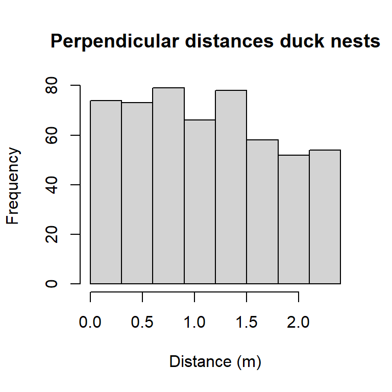

```r
# Histogram with 8 bins
brks <- seq(from=0, to=2.4, by=0.3)
hist(ducknest$distance, breaks=brks, xlab="Distance (m)",
     main="Perpendicular distances duck nests")
```

# Fit detection functions

Fit the three models using proper units of distance measure.

The answer is another function `convert_units`. Arguments to this function are

- distance_units
  - units of measure for perpendicular/radial distances
- effort_units
  - units of measure for effort (NULL for point transects)
- area_units
  - units of measure for the study area.

```r
conversion.factor <- convert_units("Meter", "Kilometer", "Square Kilometer")
# Half-normal with no adjustments
nest.hn <- ds(ducknest, key="hn", adjustment=NULL,
              convert_units=conversion.factor)
summary(nest.hn)
```

```
##
## Summary for distance analysis
## Number of observations :  534
## Distance range         :  0  -  2.4
##
## Model : Half-normal key function
## AIC   : 928.1338
##
## Detection function parameters
## Scale coefficient(s):
##              estimate        se
## (Intercept) 0.9328967 0.1703933
##
##                        Estimate          SE         CV
## Average p             0.8693482  0.03902053 0.04488481
## N in covered region 614.2533225 29.19683065 0.04753223
##
## Summary statistics:
##    Region  Area CoveredArea Effort   n  k        ER       se.ER      cv.ER
## 1 Default 12.36       12.36   2575 534 20 0.2073786 0.007970756 0.03843576
##
## Density:
##   Label Estimate       se         cv     lcl      ucl       df
## 1 Total 49.69687 2.936725 0.05909276 44.2033 55.87318 99.55689
```

In addition to the half normal key function, fit uniform and hazard rate models with possible adjustment terms.

```r
nest.uf.cos <- ds(ducknest, key="unif", adjustment="cos",
                  convert_units=conversion.factor)
nest.hr.herm <- ds(ducknest, key="hr", adjustment="herm",
                  convert_units=conversion.factor)
```

```
## Error :
## gosolnp-->Could not find a feasible starting point...exiting
##
## Error :
## gosolnp-->Could not find a feasible starting point...exiting
```

# Assess absolute model fit

The goodness of fit for the basic model is shown below.

```r
gof_ds(nest.hn, plot=FALSE)
```

```
##
## Goodness of fit results for ddf object
##
## Distance sampling Cramer-von Mises test (unweighted)
## Test statistic = 0.0353634 p-value = 0.955416
```

# Contrast competing models

A function useful for contrasting models is `summarize_ds_models`. A summary table of goodness of fit statistics for all models is created below.

```r
# Summarise gof statistics
knitr::kable(summarize_ds_models(nest.hn, nest.uf.cos, nest.hr.herm, output="plain"),
               caption="Model results for ducknest data set.", digits=3)
```

Model results for ducknest data set.

| Model | Key function | Formula | C-vM $p$-value | Average detectability | se(Average detectability) | Delta AIC |
| --- | --- | --- | --- | --- | --- | --- |
| nest.hn | Half-normal | ~1 | 0.955 | 0.869 | 0.039 | 0.000 |
| nest.uf.cos | Uniform with cosine adjustment term of order 1 | NA | 0.821 | 0.846 | 0.044 | 0.346 |
| nest.hr.herm | Hazard-rate | ~1 | 0.981 | 0.889 | 0.050 | 1.660 |

# Density estimates from the competing models

The density results from all models are summarized below.

Density estimates and confidence intervals for three fitted models.

| Model | DetectionFunction | Density | LowerCI | UpperCI |
| --- | --- | --- | --- | --- |
| 1 | Half-normal, no adjustments | 49.70 | 44.20 | 55.87 |
| 2 | Uniform, cosine adjustments | 51.04 | 44.92 | 58.00 |
| 3 | Hazard rate, no adjustments | 48.59 | 42.52 | 55.54 |

# Visualise shape of key functions with duck nest data

The detection function plots are shown below.

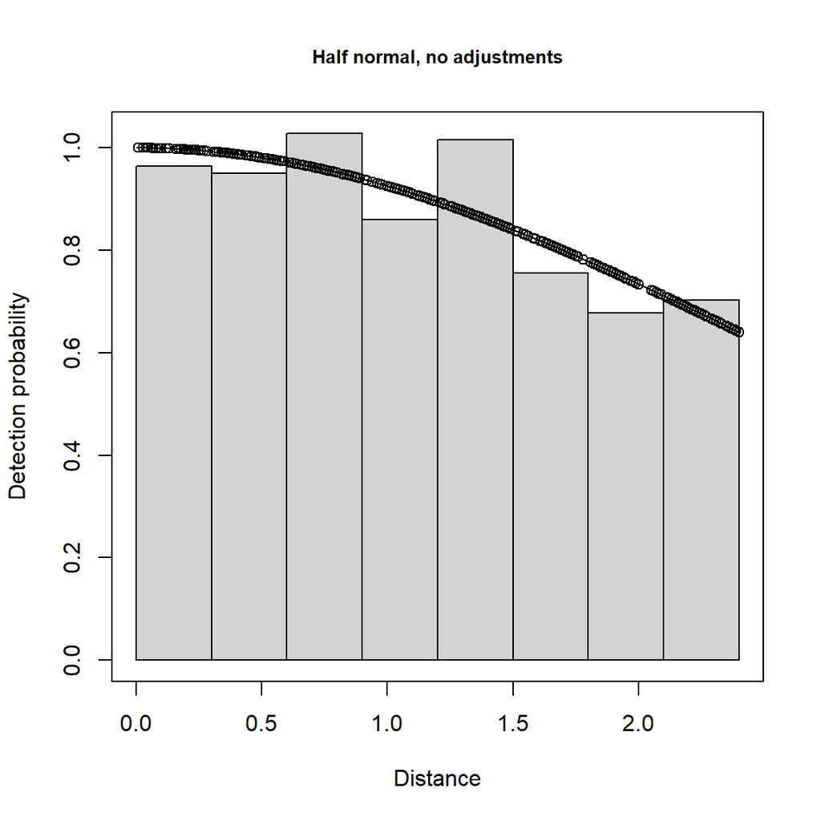

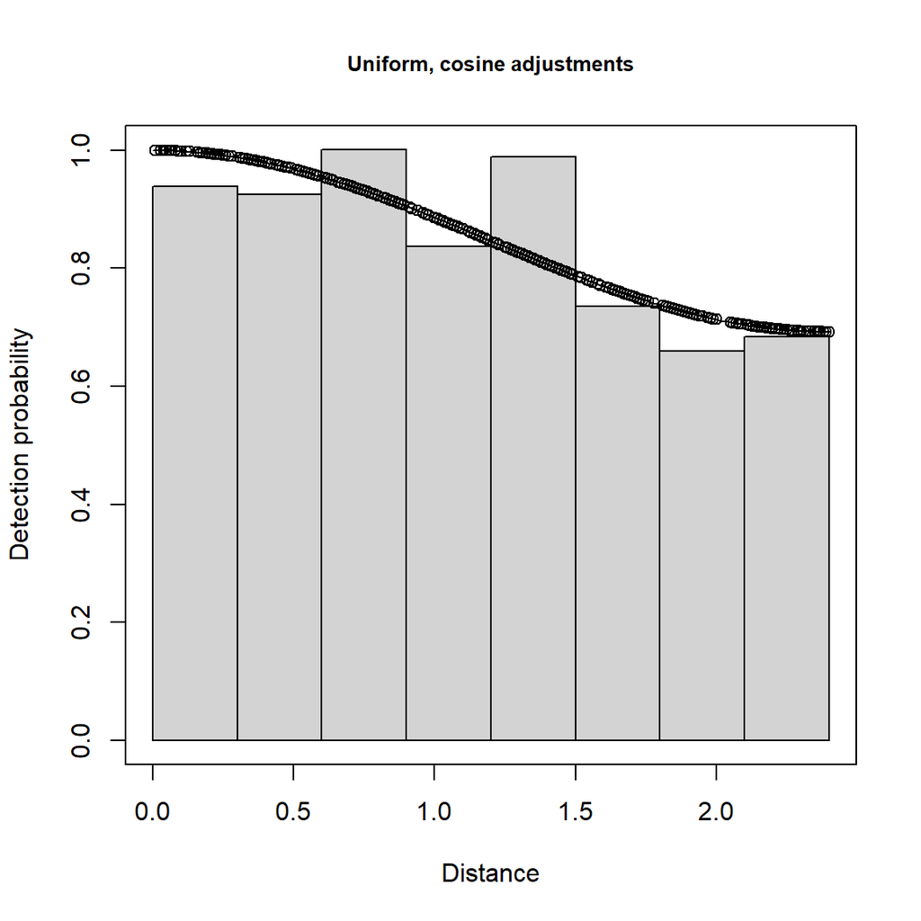

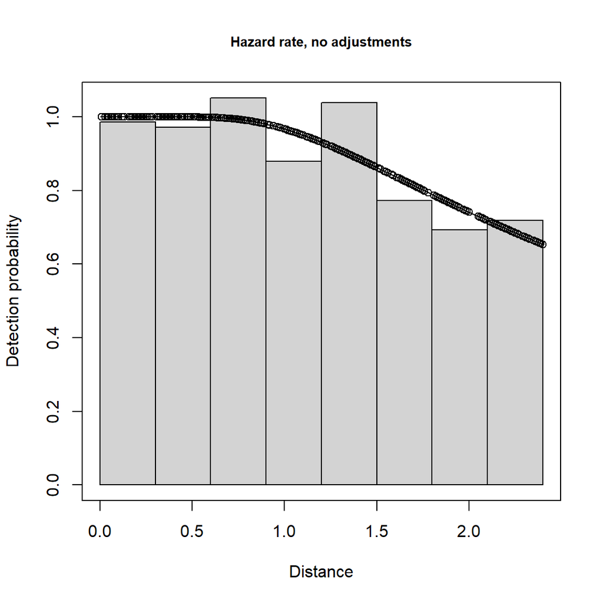

```r
plot(nest.hn, nc=8, main="Half normal, no adjustments")
plot(nest.uf.cos, nc=8, main="Uniform, cosine adjustments")
plot(nest.hr.herm, nc=8, main="Hazard rate, no adjustments")
```

The half-normal detection function with no adjustments has the smallest AIC which provides support for this model. The $\Delta$AIC values for all three models is small. In general, you should get similar density estimates using different detection function models, provided those models fit the data well, as in this example.